# Cat Daily Behaviour Visual Data Story

## What was observed?

This visual data story explores daily cat behaviour observations collected through a Google Form. Each row records the date, behaviour type, duration in minutes, location, and time of day.

The purpose of this story is to understand which behaviours appeared most often, when they happened, and which behaviours took up the most observed time.

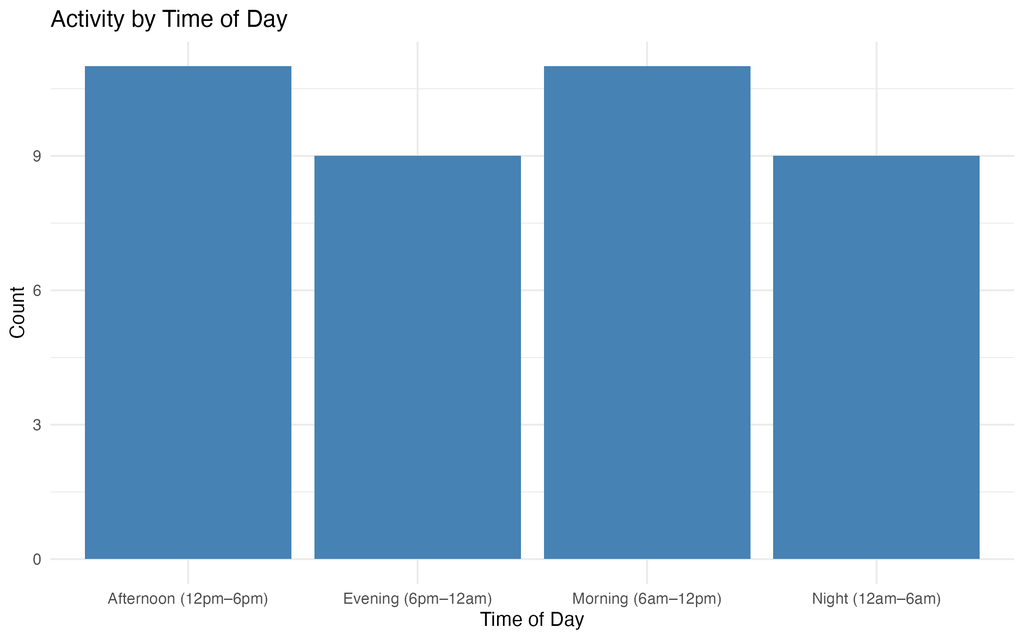

## Weekday pattern

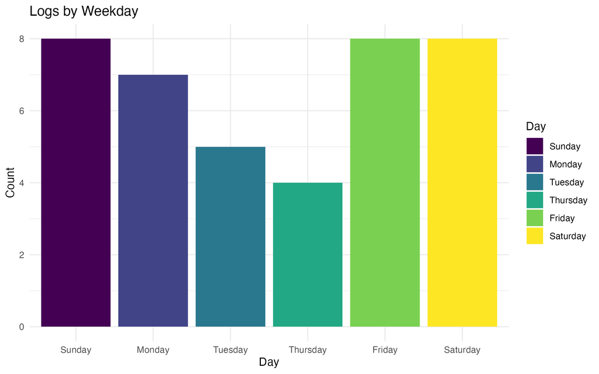

A column chart showing the number of observations by weekday.

This chart uses the timestamp variable after converting it into dates with lubridate. It shows how the number of recorded observations changed across weekdays.

## Duration and time of day

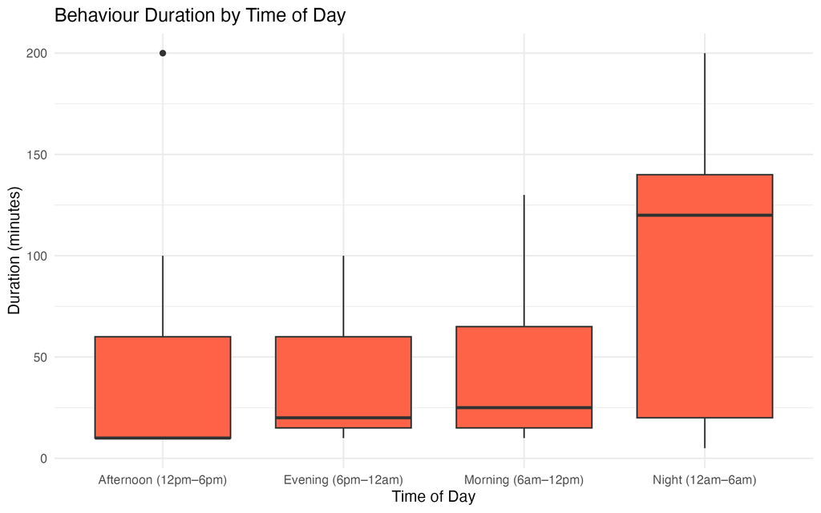

A boxplot showing behaviour duration across different times of day.

This chart compares behaviour duration across different time periods. It is useful because it does not only count behaviours, but also shows how long they lasted.

## Creative transformation

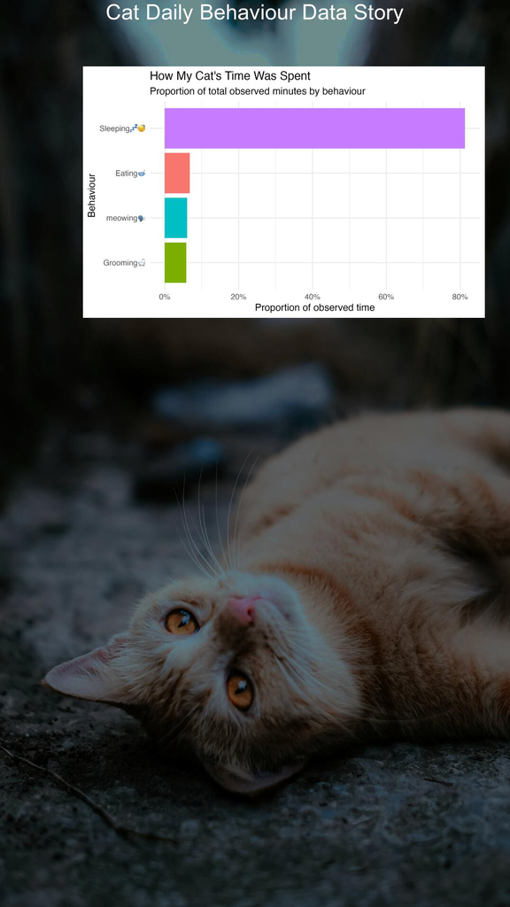

A creative chart showing proportion of total observed time spent on each behaviour.

For the creative component, I made two key modifications to the original visualisation.

First, I changed the analytical focus from frequency counts to total duration. Instead of measuring how often each behaviour occurred, I calculated the total time spent on each behaviour and converted these into proportions of overall observed time. This transformation highlights the dominance of longer-duration activities, such as sleeping, which would be less emphasised if only frequency was considered.

Second, I redesigned the presentation by integrating the statistical chart into a full-page visual layout using the magick package. The bar chart was combined with a background image of a cat to create a poster-style visual rather than a standard standalone plot. The background image provides contextual relevance, while the chart remains clearly visible and communicates the key quantitative information.

These changes alter both the interpretation and the communication of the data. The shift in measurement changes what is considered important in the dataset, while the visual integration improves engagement and readability without removing the statistical content.